# Part 2 — Design, resampling and preparation

Complete tutorial for sciModelFlowR (version 1.0.2)

Author

Walter Esfrain Pereira

Published

September 19, 2026

# 1 Why resampling decides the result

The scientific question is always “how does this model behave on new observations?”. The answer depends entirely on **what counts as a new observation**. If plots from the same farm appear in training and testing, the model memorises the farm and the estimate becomes optimistic. If preprocessing is fitted on the whole dataset before splitting, the test median leaks into training. `sciModelFlowR` treats resampling as part of the **design**: `smf_design_spec()` declares groups, blocks, time and coordinates, and the package refuses incompatible schemes instead of warning.

# 2 Resampling schemes

Each simulated dataset has a structure that calls for its own scheme. The table shows what was declared and what was built.

```r
field <- ler("field_yield")
farms <- ler("farm_groups")
climate <- ler("climate_series")
soil <- ler("soil_spatial")

h <- smf_holdout_split(field, train_prop = 0.7, id_column = "plot_id", seed = 101L)
v <- smf_vfold_cv(field, v = 5L, id_column = "plot_id", seed = 102L)
gv <- smf_group_vfold_cv(farms, groups = "farm", v = 6L, id_column = "plot_id", seed = 103L)
tc <- smf_time_cv(climate, time = "day", initial = 400L, assess = 100L, id_column = "day", seed = 104L)
sc <- smf_spatial_cv(soil, coords = c("x", "y"), v = 4L, id_column = "point_id", seed = 105L)

scheme_summary <- data.frame(
  scheme = c("holdout (70/30)", "v-fold (v = 5)", "group v-fold (farm)",
             "time series CV", "spatial CV"),
  partitions = c(1L, length(v@splits), length(gv@splits), length(tc@splits), length(sc@splits)),
  property = c("one random (stratifiable) split",
               "each unit in the test set exactly once",
               "whole farms out of training",
               "past trains, future tests",
               "whole spatial blocks out of training")
)
tab_smf(scheme_summary, caption = "Resampling schemes built for each data structure.")
```

Resampling schemes built for each data structure.

| scheme | partitions | property |
| --- | --- | --- |
| holdout (70/30) | 1 | one random (stratifiable) split |
| v-fold (v = 5) | 5 | each unit in the test set exactly once |
| group v-fold (farm) | 6 | whole farms out of training |
| time series CV | 3 | past trains, future tests |
| spatial CV | 4 | whole spatial blocks out of training |

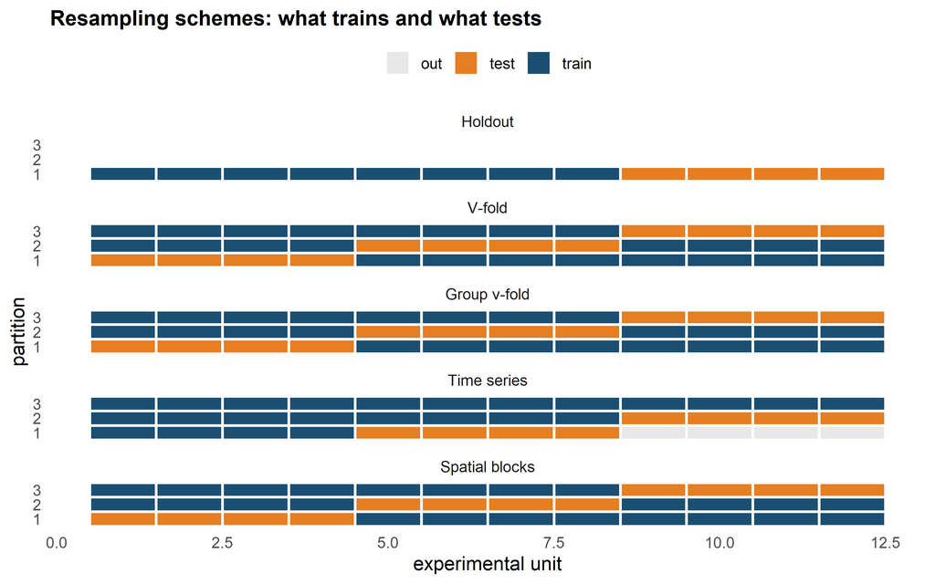

Figure 1: How each scheme partitions the data: training in blue, testing in orange. The wrong scheme puts neighbours on both sides of the border.

```r
units <- 1:12
block <- function(name, folds, role_of) {
  do.call(rbind, lapply(folds, function(f) data.frame(
    scheme = name, unit = units, fold = f, role = role_of(f)
  )))
}
scheme_df <- rbind(
  block("Holdout", 1L, function(f) ifelse(units <= 8, "train", "test")),
  block("V-fold", 1:3, function(f) ifelse(ceiling(units / 4) == f, "test", "train")),
  block("Group v-fold", 1:3, function(f) ifelse(ceiling(units / 4) == f, "test", "train")),
  block("Time series", 1:3, function(f) ifelse(units > 4 * f & units <= 4 * (f + 1),
                                               "test", ifelse(units <= 4 * f, "train", "out"))),
  block("Spatial blocks", 1:3, function(f) ifelse(ceiling(units / 4) == f, "test", "train"))
)
scheme_df$scheme <- factor(scheme_df$scheme, levels = c("Holdout", "V-fold", "Group v-fold",
                                                        "Time series", "Spatial blocks"))
ggplot(scheme_df, aes(unit, factor(fold), fill = role)) +
  geom_tile(colour = "white", linewidth = .8) +
  facet_wrap(~scheme, ncol = 1) +
  scale_fill_manual(values = c(train = cores_smf[["primaria"]],
                               test = cores_smf[["destaque"]],
                               out = "#e8e8e8")) +
  labs(x = "experimental unit", y = "partition", fill = NULL,
       title = "Resampling schemes: what trains and what tests") +
  theme(legend.position = "top", panel.grid = element_blank())
```

**NoteInterpretation**

In ordinary v-fold, neighbours from the same farm (or the same spatial block) appear on both sides of the border. In the `group`, `time series` and `spatial` schemes, the border respects dependence: the whole farm leaves, the future does not train the past, the whole spatial block is held out. Choosing the scheme **is** a scientific decision — and it must be declared.

# 3 The price of leakage, measured

The best way to learn is to watch the error happen. The package **refuses** ordinary v-fold when groups are declared:

```r
spec_iid <- smf_experiment_spec(
  task = smf_task_spec("regression", "yield"),
  data = smf_data_spec("yield", c("nitrogen", "farm"), id_column = "plot_id",
                       categorical = "farm"),
  design = smf_design_spec(id_column = "plot_id", group_columns = "farm"),
  preprocessing = smf_preprocess_spec("median", center = TRUE, scale = TRUE),
  resampling = smf_resampling_spec("kfold", n_splits = 6L, seed = 11L),
  model = smf_model_spec("linear_regression", "stats"),
  metrics = list(smf_metric_spec("rmse")),
  reproducibility = smf_reproducibility_spec(11L)
)
refusal <- tryCatch(smf_resample_experiment(spec_iid, farms),
                    error = function(e) conditionMessage(e))
cat(refusal, "\n")
```

```
Row-wise random resampling is incompatible with declared grouped/repeated units by default.
```

To **quantify** the optimism, we force the same scheme with `override = TRUE` and compare with the correct scheme. The model includes the farm as a predictor: with ordinary v-fold, the model learns each farm’s effect from the other plots and nails the test set; with `group`, the test farm is unseen.

```r
spec_grp <- smf_experiment_spec(
  task = smf_task_spec("regression", "yield"),
  data = smf_data_spec("yield", c("nitrogen", "farm"), id_column = "plot_id",
                       categorical = "farm"),
  design = smf_design_spec(id_column = "plot_id", group_columns = "farm"),
  preprocessing = smf_preprocess_spec("median", center = TRUE, scale = TRUE),
  resampling = smf_resampling_spec("group", n_splits = 6L, seed = 11L),
  model = smf_model_spec("linear_regression", "stats"),
  metrics = list(smf_metric_spec("rmse")),
  reproducibility = smf_reproducibility_spec(11L)
)
res_iid <- smf_resample_experiment(spec_iid, farms, override = TRUE)
res_grp <- smf_resample_experiment(spec_grp, farms)
rmse_iid <- res_iid@aggregate$mean[res_iid@aggregate$metric == "rmse"]
rmse_grp <- res_grp@aggregate$mean[res_grp@aggregate$metric == "rmse"]
```

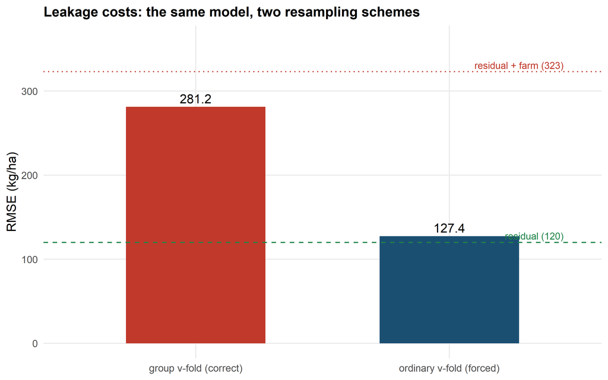

Figure 2: The same model, two schemes: forced ordinary v-fold returns a much smaller RMSE than group v-fold. Lines mark the simulated truth.

```r
leak_df <- data.frame(
  scheme = c("ordinary v-fold (forced)", "group v-fold (correct)"),
  rmse = c(rmse_iid, rmse_grp)
)
ggplot(leak_df, aes(scheme, rmse, fill = scheme)) +
  geom_col(width = .55, show.legend = FALSE) +
  geom_hline(yintercept = verdade$farm_groups$residual_sd, linetype = "dashed",
             colour = cores_smf[["sucesso"]]) +
  geom_hline(yintercept = sqrt(verdade$farm_groups$residual_sd^2 +
                               verdade$farm_groups$farm_sd^2),
             linetype = "dotted", colour = cores_smf[["alerta"]]) +
  geom_text(aes(label = fmt(rmse, 1)), vjust = -0.4) +
  scale_fill_manual(values = c(cores_smf[["alerta"]], cores_smf[["primaria"]])) +
  annotate("text", x = 2.45, y = verdade$farm_groups$residual_sd, hjust = 1, vjust = -0.4,
           label = "residual (120)", colour = cores_smf[["sucesso"]], size = 3.2) +
  annotate("text", x = 2.45, y = sqrt(verdade$farm_groups$residual_sd^2 +
           verdade$farm_groups$farm_sd^2), hjust = 1, vjust = -0.4,
           label = "residual + farm (323)", colour = cores_smf[["alerta"]], size = 3.2) +
  labs(x = NULL, y = "RMSE (kg/ha)",
       title = "Leakage costs: the same model, two resampling schemes") +
  ylim(0, 360)
```

**ImportantInterpretation**

# 4 Bootstrap: the right unit changes the interval

The bootstrap answers “how much does this estimate vary if the experiment were repeated?”. The answer is only honest if the resampling respects the unit that varies between repetitions. In the farm trial, the unit is the **farm**, not the plot.

```r
b_case <- tryCatch(
  smf_bootstrap(farms, smf_bootstrap_spec("case", n_resamples = 99L,
                                          interval = "percentile", seed = 7L),
                statistic = function(z) c(mean = mean(z$yield)),
                design = smf_design_spec(id_column = "plot_id",
                                         group_columns = "farm")),
  error = function(e) conditionMessage(e))
b_bca_cl <- tryCatch(
  smf_bootstrap(farms, smf_bootstrap_spec("cluster", n_resamples = 99L,
                                          sampling_unit = "farm",
                                          interval = "bca", seed = 7L),
                statistic = function(z) c(mean = mean(z$yield)),
                design = smf_design_spec(id_column = "plot_id",
                                         group_columns = "farm")),
  error = function(e) conditionMessage(e))
cat("case (iid):", b_case, "\n\n")
```

```
case (iid): The requested bootstrap unit does not preserve dependence declared in DesignSpec.
```

```r
cat("BCa with cluster:", b_bca_cl, "\n")
```

```
BCa with cluster: The generic row-delete BCa implementation is available only for case bootstrap; other dependence-aware schemes require a scheme-specific jackknife and are blocked rather than approximated.
```

```r
b_cl <- smf_bootstrap(farms,
  smf_bootstrap_spec("cluster", n_resamples = 1999L, sampling_unit = "farm",
                     interval = "percentile", seed = 7L),
  statistic = function(z) c(mean = mean(z$yield)),
  design = smf_design_spec(id_column = "plot_id", group_columns = "farm"))
ci_cl <- smf_bootstrap_interval(b_cl)
stability <- smf_bootstrap_stability(b_cl)
```

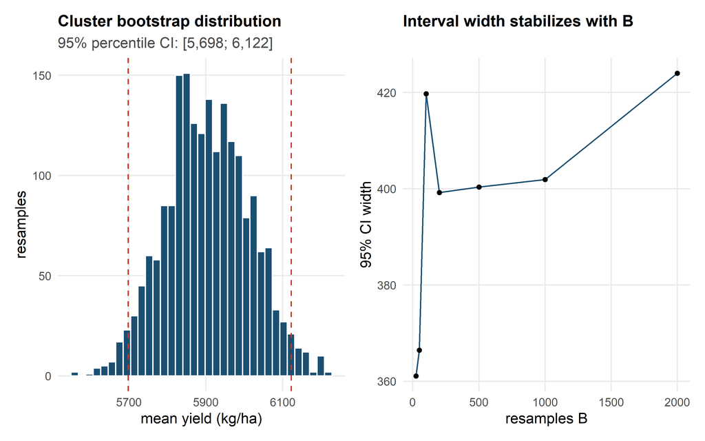

```r
p1 <- ggplot(data.frame(mean = b_cl@estimates[[1]]), aes(mean)) +
  geom_histogram(fill = cores_smf[["primaria"]], colour = "white", bins = 35) +
  geom_vline(xintercept = ci_cl["mean", ], linetype = "dashed",
             colour = cores_smf[["alerta"]]) +
  labs(x = "mean yield (kg/ha)", y = "resamples",
       title = "Cluster bootstrap distribution",
       subtitle = paste0("95% percentile CI: [", fmt(ci_cl["mean", 1], 0),
                         "; ", fmt(ci_cl["mean", 2], 0), "]"))
p2 <- ggplot(subset(stability, statistic == "mean"), aes(B, width)) +
  geom_line(colour = cores_smf[["primaria"]]) +
  geom_point(size = 1.4) +
  labs(x = "resamples B", y = "95% CI width",
       title = "Interval width stabilizes with B")
patchwork::wrap_plots(p1, p2)
```

**WarningTrap**

The `case` bootstrap (plot by plot) was **refused** because it would underestimate variability: plots from the same farm are not independent repetitions. BCa with cluster was also refused — bias correction would need a scheme-specific jackknife, and the package prefers to block rather than approximate. Both blocks are the same philosophy: **an explicit error is better than a plausible, wrong number**.

# 5 Preparation: imputation, centring and scaling

Part 1 showed two kinds of missingness: MCAR in nitrogen and MAR (block B4) in organic matter. Before comparing imputation strategies, however, one mandatory step: **the outliers**. The table below shows the organic-matter coefficient (planted truth: 120) in four scenarios.

```r
no_out <- field[!field$plot_id %in% verdade$field_yield$outlier_ids, ]
dspec <- smf_data_spec("yield", c("nitrogen", "water", "organic_matter"),
                       id_column = "plot_id")
om_coef <- function(data, imp) {
  pp <- smf_fit_preprocessor(data, smf_preprocess_spec(imp), dspec, role = "training")
  tr <- smf_apply_preprocessor(pp, data)
  tr[["yield"]] <- data[["yield"]]
  fit <- lm(yield ~ nitrogen + water + organic_matter, data = tr)
  c(slope = unname(coef(fit)[["organic_matter"]]),
    n = sum(stats::complete.cases(tr)))
}
c_all <- om_coef(field, "none")
c_none <- om_coef(no_out, "none")
c_mean <- om_coef(no_out, "mean")
c_med <- om_coef(no_out, "median")
imp_tbl <- data.frame(
  scenario = c("all data, no imputation",
               "no outliers, no imputation (complete cases)",
               "no outliers, mean imputation",
               "no outliers, median imputation"),
  om_coef = c(c_all["slope"], c_none["slope"], c_mean["slope"], c_med["slope"]),
  rows_used = c(c_all["n"], c_none["n"], c_mean["n"], c_med["n"])
)
tab_smf(imp_tbl, caption = "Organic-matter coefficient under different discrepancy-handling decisions (planted truth: 120).")
```

Organic-matter coefficient under different discrepancy-handling decisions (planted truth: 120).

| scenario | om_coef | rows_used |
| --- | --- | --- |
| all data, no imputation | 285.808 | 153 |
| no outliers, no imputation (complete cases) | 115.286 | 149 |
| no outliers, mean imputation | 198.395 | 175 |
| no outliers, median imputation | 206.427 | 175 |

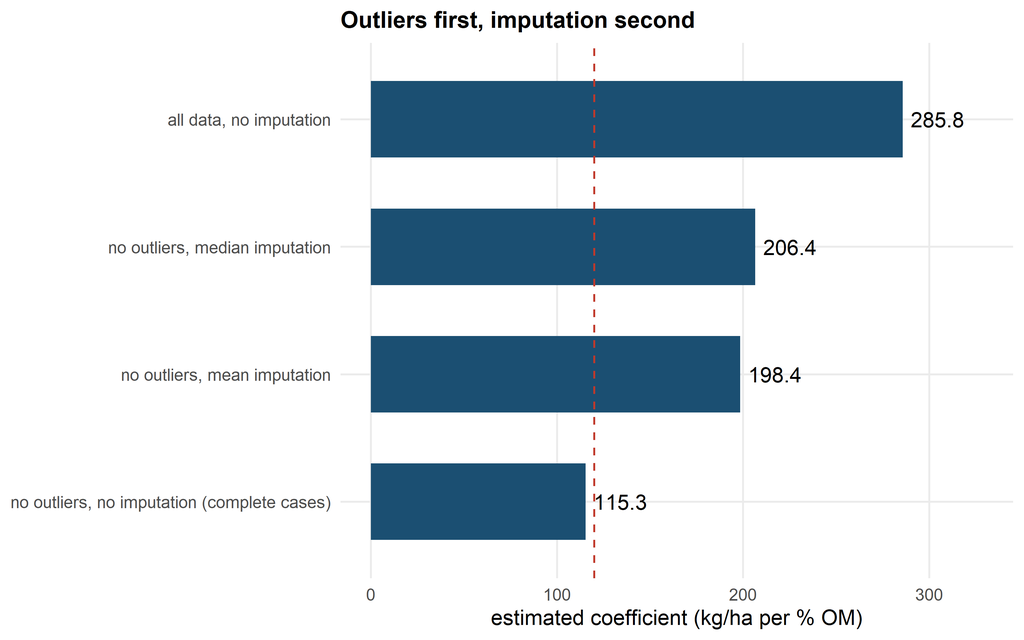

Figure 4: The organic-matter coefficient: outliers dominate the error; once removed, the imputation choice still shifts the estimate.

```r
ggplot(imp_tbl, aes(stats::reorder(scenario, om_coef), om_coef)) +
  geom_col(fill = cores_smf[["primaria"]], width = .6) +
  geom_hline(yintercept = verdade$field_yield$beta[["organic_matter"]],
             linetype = "dashed", colour = cores_smf[["alerta"]]) +
  geom_text(aes(label = fmt(om_coef, 1)), hjust = -0.15) +
  coord_flip() +
  labs(x = NULL, y = "estimated coefficient (kg/ha per % OM)",
       title = "Outliers first, imputation second") +
  ylim(0, max(imp_tbl$om_coef) * 1.15)
```

**ImportantInterpretation**

```r
coef_scale <- function(center, scale) {
  pp <- smf_fit_preprocessor(no_out, smf_preprocess_spec("median", center = center,
                                                         scale = scale),
                             dspec, role = "training")
  tr <- smf_apply_preprocessor(pp, no_out)
  tr[["yield"]] <- no_out[["yield"]]
  fit <- lm(yield ~ nitrogen + water + organic_matter, data = tr)
  round(coef(fit)[-1], 3)
}
scale_tbl <- rbind(
  "no centre, no scale" = coef_scale(FALSE, FALSE),
  "centred" = coef_scale(TRUE, FALSE),
  "centred and scaled" = coef_scale(TRUE, TRUE)
)
tab_smf(as.data.frame(scale_tbl), caption = "Effect of centring and scaling on coefficients: centring does not change slopes; scaling changes the unit.")
```

Effect of centring and scaling on coefficients: centring does not change slopes; scaling changes the unit.

|  | nitrogen | water | organic_matter |
| --- | --- | --- | --- |
| no centre, no scale | 24.004 | 2.744 | 206.427 |
| centred | 24.004 | 2.744 | 206.427 |
| centred and scaled | 1044.576 | 302.382 | 91.741 |

**TipGood practice**

Centring does not change slopes (it only shifts the intercept). Scaling changes the unit of the coefficient — and is essential for comparing the importance of predictors on different scales. The package fits preprocessing **inside each fold**; in Parts 3 and 4 this happens automatically inside `smf_fit_experiment()` and `smf_resample_experiment()`.

# 6 Imbalance: touch training only

```r
disease <- ler("disease_binary")
disease$disease <- factor(disease$disease, levels = c(0, 1))
```

In the disease dataset, the positive class is 13.8% and label noise caps the ceiling. Balancing strategies resample **training**; testing stays untouched.

```r
balance_tbl <- do.call(rbind, lapply(c("none", "downsample", "upsample", "smote"), function(m) {
  out <- tryCatch(smf_apply_imbalance(disease, "disease", smf_imbalance_spec(m),
                                      context = "training", seed = 20260919),
                  error = function(e) conditionMessage(e))
  if (is.character(out)) {
    data.frame(method = m, class_0 = NA_integer_, class_1 = NA_integer_,
               note = out)
  } else {
    data.frame(method = m,
               class_0 = sum(out@data$disease == "0"),
               class_1 = sum(out@data$disease == "1"),
               note = "")
  }
}))
tab_smf(balance_tbl, caption = "Class counts before and after each balancing strategy (training only).")
```

Class counts before and after each balancing strategy (training only).

| method | class_0 | class_1 | note |
| --- | --- | --- | --- |
| none | 345 | 55 |  |
| downsample | 55 | 55 |  |
| upsample | 345 | 345 |  |
| smote | NA | NA | Error in `step_smote()`: |

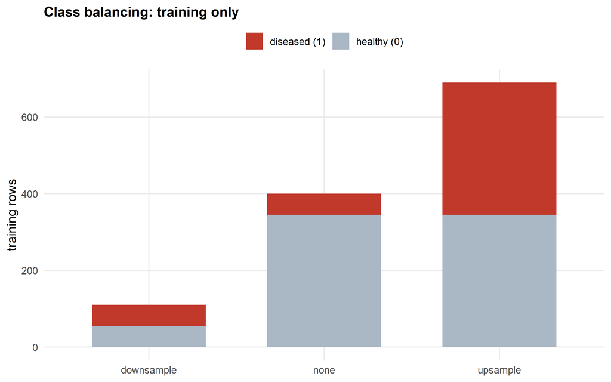

Figure 5: Balancing on training: downsample equalises classes by shrinking the majority; upsample equalises by replicating the minority; testing is never touched.

```r
balance_long <- data.frame(
  method = rep(balance_tbl$method, 2),
  class = rep(c("healthy (0)", "diseased (1)"), each = nrow(balance_tbl)),
  n = c(balance_tbl$class_0, balance_tbl$class_1)
)
ggplot(subset(balance_long, !is.na(n)), aes(method, n, fill = class)) +
  geom_col(width = .65) +
  scale_fill_manual(values = c("healthy (0)" = cores_smf[["claro"]],
                               "diseased (1)" = cores_smf[["alerta"]])) +
  labs(x = NULL, y = "training rows", fill = NULL,
       title = "Class balancing: training only") +
  theme(legend.position = "top")
```

**WarningTrap**

# 7 Feature selection and representation

Selecting features on the whole dataset is a subtle form of leakage. The correct path is to select **inside each fold**. The result carries per-fold scores and a stability measure.

```r
cv_field <- smf_vfold_cv(no_out, v = 5L, id_column = "plot_id", seed = 9L)
sel <- smf_feature_select_resamples(
  no_out, "yield", smf_feature_spec("mutual_information", n_features = 3L),
  cv_field, id_column = "plot_id"
)
sel_tbl <- merge(sel@scores, sel@stability, by = "feature", all = TRUE)
tab_smf(sel_tbl, caption = "Mutual-information selection (3 features per fold) repeated over 5 folds: selection frequency and stability per feature.")
```

Mutual-information selection (3 features per fold) repeated over 5 folds: selection frequency and stability per feature.

| feature | selection_frequency | frequency |
| --- | --- | --- |
| block | 0.0 | 0.0 |
| genotype | 0.0 | 0.0 |
| nitrogen | 1.0 | 1.0 |
| organic_matter | 0.6 | 0.6 |
| potassium | 0.6 | 0.6 |
| water | 0.8 | 0.8 |

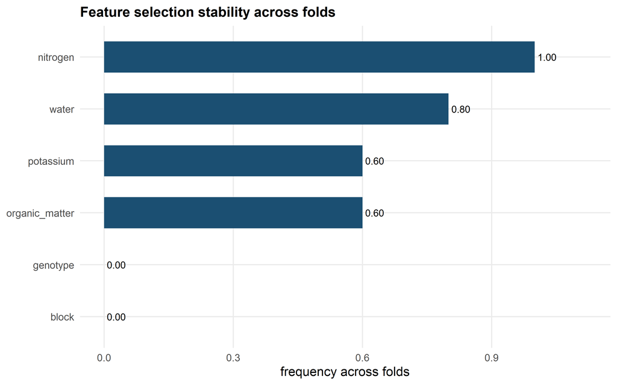

Figure 6: Selection stability across folds: features chosen in every fold are the reliable candidates.

```r
stability_sel <- sel@stability
names(stability_sel)[2] <- "frequency"
ggplot(stability_sel, aes(stats::reorder(feature, frequency), frequency)) +
  geom_col(fill = cores_smf[["primaria"]], width = .6) +
  geom_text(aes(label = fmt(frequency, 2)), hjust = -0.15, size = 3.2) +
  coord_flip() +
  labs(x = NULL, y = "frequency across folds",
       title = "Feature selection stability across folds") +
  ylim(0, 1.12)
```

In high dimension (200 wavelengths for 120 samples), the solution is **representation**: PCA or PLS reduce dimensionality before the model, always fitted on training. The experiment below uses the PCA representation declared in the specification.

```r
spectral <- ler("spectral_pn")
waves <- grep("^w", names(spectral), value = TRUE)
make_rep <- function(k) {
  spec <- smf_experiment_spec(
    task = smf_task_spec("regression", "protein"),
    data = smf_data_spec("protein", waves, id_column = "sample_id"),
    design = smf_design_spec(id_column = "sample_id"),
    features = smf_feature_spec("pca", n_features = k, representation = "pca"),
    resampling = smf_resampling_spec("holdout", train_prop = 0.75, seed = 4L),
    model = smf_model_spec("linear_regression", "stats"),
    metrics = list(smf_metric_spec("rmse")),
    reproducibility = smf_reproducibility_spec(4L)
  )
  smf_fit_experiment(spec, spectral)
}
fit_rep <- make_rep(8L)
var_exp <- cumsum(fit_rep@fit@features@state$sdev^2) /
  sum(fit_rep@fit@features@state$sdev^2)
tab_smf(data.frame(component = seq_along(var_exp),
                   cumulative_variance = var_exp),
        caption = "Cumulative variance of the principal components fitted on training.")
```

Cumulative variance of the principal components fitted on training.

| component | cumulative_variance |
| --- | --- |
| 1 | 0.468 |
| 2 | 0.756 |
| 3 | 0.992 |
| 4 | 0.993 |
| 5 | 0.993 |
| 6 | 0.993 |
| 7 | 0.994 |
| 8 | 0.994 |
| 9 | 0.994 |
| 10 | 0.994 |
| 11 | 0.995 |
| 12 | 0.995 |
| 13 | 0.995 |
| 14 | 0.995 |
| 15 | 0.995 |
| 16 | 0.996 |
| 17 | 0.996 |
| 18 | 0.996 |
| 19 | 0.996 |
| 20 | 0.996 |
| 21 | 0.996 |
| 22 | 0.997 |
| 23 | 0.997 |
| 24 | 0.997 |
| 25 | 0.997 |
| 26 | 0.997 |
| 27 | 0.997 |
| 28 | 0.997 |
| 29 | 0.998 |
| 30 | 0.998 |

[output cut: 60 more lines]

```r
rmse_comp <- do.call(rbind, lapply(c(2L, 4L, 6L, 8L, 12L, 20L), function(k) {
  f <- make_rep(k)
  data.frame(components = k,
             rmse = f@metrics$value[f@metrics$metric == "rmse"])
}))
tab_smf(rmse_comp, caption = "Validation RMSE by number of principal components (true noise: 0.25).")
```

Validation RMSE by number of principal components (true noise: 0.25).

| components | rmse |
| --- | --- |
| 2 | 0.946 |
| 4 | 0.306 |
| 6 | 0.307 |
| 8 | 0.307 |
| 12 | 0.302 |
| 20 | 0.331 |

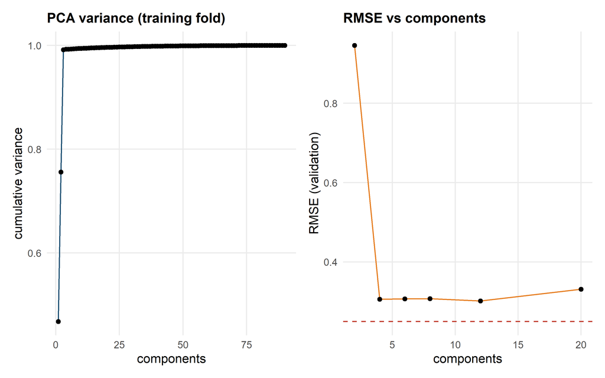

Figure 7: PCA representation: cumulative variance (left) and validation RMSE by number of components (right).

```r
p_var <- ggplot(data.frame(component = seq_along(var_exp), var = var_exp),
                aes(component, var)) +
  geom_line(colour = cores_smf[["primaria"]]) +
  geom_point(size = 1.6) +
  labs(x = "components", y = "cumulative variance",
       title = "PCA variance (training fold)")
p_rmse <- ggplot(rmse_comp, aes(components, rmse)) +
  geom_line(colour = cores_smf[["destaque"]]) +
  geom_point(size = 1.6) +
  geom_hline(yintercept = 0.25, linetype = "dashed", colour = cores_smf[["alerta"]]) +
  labs(x = "components", y = "RMSE (validation)",
       title = "RMSE vs components")
patchwork::wrap_plots(p_var, p_rmse)
```

**NoteInterpretation**

# 8 Part 2 exercises

**NoteExercise 2.1 — Prove the leakage**

In ordinary v-fold on `farm_groups` (with `override = TRUE`), count how many farms appear on both sides of each fold. Then repeat with `group v-fold` and show the count is zero. (Hint: `s@train_index`, `s@test_index` and `farms$farm`.)

**NoteExercise 2.2 — Verify the time order**

In `smf_time_cv()` on `climate_series`, confirm that in **every** fold the test day comes after the last training day. Then redo it with `smf_vfold_cv()` and show a case where the order is violated.

**NoteExercise 2.3 — When does leakage disappear?**

Repeat the v-fold vs group v-fold comparison **without** the `farm` column in the predictors. Does the optimism persist? Explain why, and what this teaches about when the wrong scheme is harmless (and why it is still risky).

**NoteExercise 2.4 — MCAR versus MAR in imputation**

Compare the nitrogen coefficient (MCAR) and the organic-matter coefficient (MAR) under the three imputation strategies. Which coefficient is more sensitive? Relate it to the missingness pattern seen in Part 1.

**CautionSolutions**

**2.1.** With forced ordinary v-fold, every fold has plots from farms that are also in training (overlap > 0 in all folds). In `group v-fold`, the train ∩ test farm intersection is zero by construction.

**2.2.** In `smf_time_cv()`, `max(train) < min(test)` in all folds (expansion into the future). In `smf_vfold_cv()`, since the split is random, some fold will have test days earlier than training days — the model “learns the future”.

**2.3.** Without `farm` in the predictors, the model cannot memorise the farm effect: the optimism essentially disappears. But it remains risky: it suffices that **some** attribute carries farm information (soil, local climate, management practice) for leakage to return. The right design does not depend on the model “not being able” to exploit leakage.

**2.4.** The organic-matter coefficient (MAR, block-dependent) is more sensitive: missingness concentrates in B4, and global-mean imputation ignores that structure. Nitrogen (MCAR) suffers less. The Part 1 diagnostic (missingness by block) already predicted this.